# An Analysis of Obesity Prevalence and Associated Factors in Scotland (2008–2012)

Author

Group 1

# 1 Introduction

Obesity is a major public health concern, associated with an increased risk of chronic conditions such as cardiovascular disease, type 2 diabetes, and certain cancers. Understanding how obesity prevalence changes over time, and how it is influenced by demographic, socio-economic, and lifestyle factors, is essential for informing effective health policy and interventions. This report analyses data from the Scottish Health Surveys conducted between 2008 and 2012. The dataset includes individual-level information on age, sex, educational attainment, dietary behaviours (fruit and vegetable consumption), and obesity status. These variables provide a valuable opportunity to explore both temporal trends and potential risk factors associated with obesity within the Scottish population. The primary aim of this analysis is to assess whether the prevalence of obesity in Scotland has changed over the period 2008–2012. In addition, the report investigates whether obesity varies across key demographic groups, socio-economic indicators, and lifestyle behaviours.

# 2 Exploratory Analysis

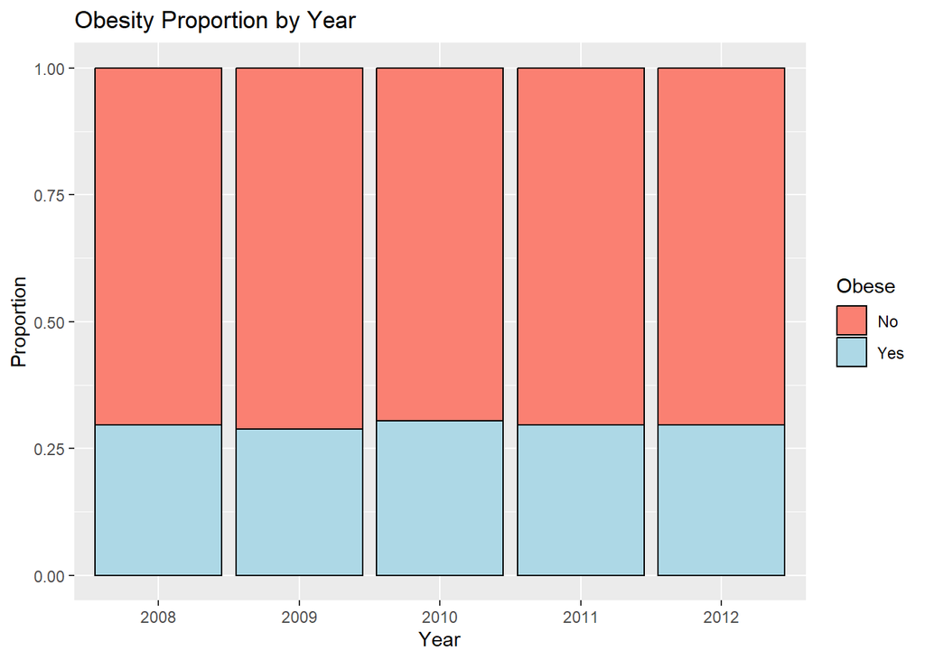

Figure 1: Obesity by Year Bar Plot

The bars in Figure 1 appear to be fairly consistent. This indicates that the prevalence of obesity across Scotland over the years in the survey has not changed much, although it may be more clear from Table 1 .

Table 1: prevelance comparison table

Obesity Prevalence by Year

| Year | Obese | Total | Prevalence |
| --- | --- | --- | --- |
| 2008 | 1448 | 4897 | 0.296 |
| 2009 | 1647 | 5721 | 0.288 |
| 2010 | 1666 | 5467 | 0.305 |
| 2011 | 1620 | 5464 | 0.296 |
| 2012 | 1088 | 3675 | 0.296 |

Now using Table 1 we see that the prevalence of obesity is 0.296 in 2008, 2011 and 2012. It slightly dropped in 2009 and peaked in 2010 but not enough to infer that the prevalence changed over the years. Furthermore, these two outliers are still very close to 0.296.

Table 2: summary table

Obesity prevalence by sex, age group, education level, and lifestyle factors.

| Subgroup | N | Obese (%) |
| --- | --- | --- |
| **Sex** |  |  |
| Female | 13960 | 29.8 |
| Male | 11264 | 29.4 |
| **Age Group** |  |  |
| 16–24 | 2063 | 15.0 |
| 25–34 | 3331 | 21.6 |
| 35–44 | 4485 | 29.9 |
| 45–54 | 4898 | 31.4 |
| 55–64 | 4566 | 36.0 |
| 65–74 | 3713 | 35.0 |
| 75+ | 2168 | 28.5 |
| **Education** |  |  |
| Degree or higher | 6891 | 24.8 |
| HNC/D or equiv | 2598 | 28.8 |
| Higher grade or equiv | 3717 | 26.8 |
| No qualifications | 5298 | 36.5 |
| Other school level | 1875 | 33.4 |
| Standard grade or equiv | 4845 | 30.2 |
| **Lifestyle** |  |  |
| Veg: No, Fruit: No | 2626 | 30.0 |
| Veg: No, Fruit: Yes | 2801 | 34.0 |
| Veg: Yes, Fruit: No | 5136 | 29.0 |
| Veg: Yes, Fruit: Yes | 14661 | 28.9 |

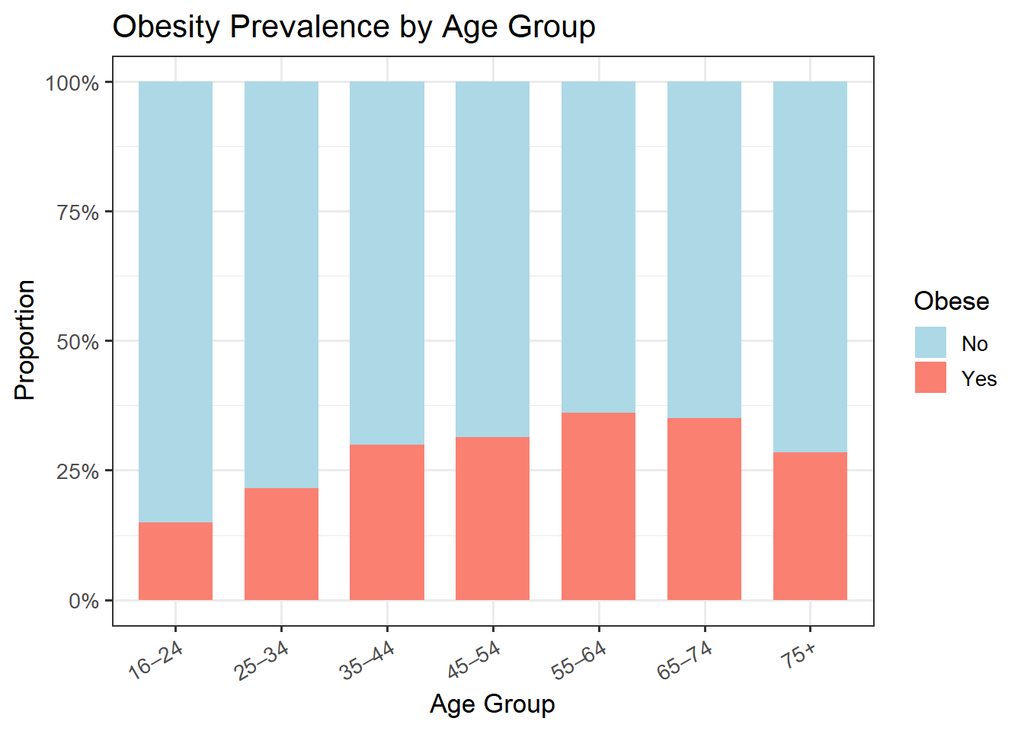

Figure 2: Obesity Prevalence by Age Group

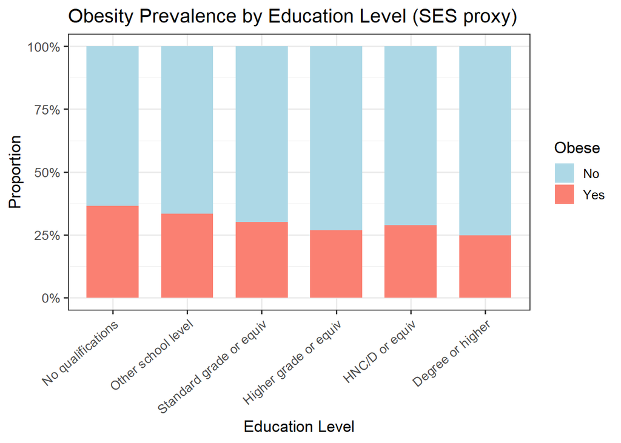

Figure 3: Obesity Prevalence by Education Level (SES proxy)

Figure 3 points to a fairly consistent socioeconomic gradient: those with no qualifications have the highest obesity rates, and the proportion falls as education level rises. This sits well with wider public health evidence linking lower socioeconomic position to worse health outcomes.

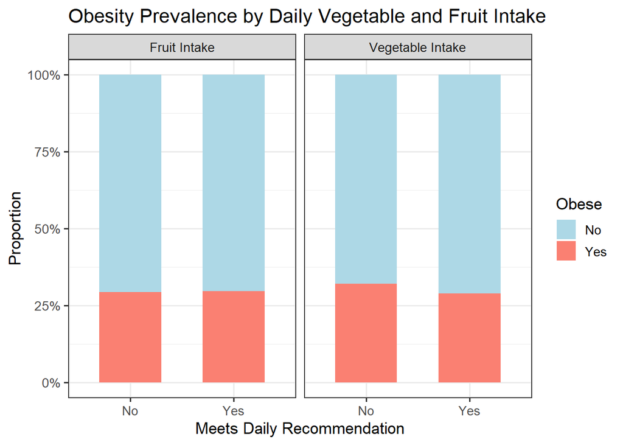

Figure 4: Obesity Prevalence by Daily Vegetable and Fruit Intake

# 3 Formal Analysis

Since obesity status `Obese` is a binary outcome variable (Yes/No), a binary logistic regression model was used. First, survey year was included as a categorical predictor so that obesity prevalence could vary freely across the five survey years. The null hypothesis for this model was that obesity prevalence was the same across all years. A likelihood ratio test was used to assess the overall effect of year.

To assess whether there was evidence of a linear time trend, a second logistic regression model was fitted with year treated as a continuous numeric variable. Odds ratios (ORs), 95% confidence intervals, and p-values were used to interpret the results.

```
Call:
glm(formula = Obese ~ Year, family = binomial, data = dat)

Coefficients:
             Estimate Std. Error z value Pr(>|z|)
(Intercept) -0.867901   0.031314 -27.716   <2e-16 ***
Year2009    -0.037769   0.042816  -0.882    0.378
Year2010     0.043062   0.042940   1.003    0.316
Year2011     0.003814   0.043104   0.088    0.929
Year2012     0.001743   0.047814   0.036    0.971
---
Signif. codes:  0 '***' 0.001 '**' 0.01 '*' 0.05 '.' 0.1 ' ' 1

(Dispersion parameter for binomial family taken to be 1)

    Null deviance: 30649  on 25223  degrees of freedom
Residual deviance: 30645  on 25219  degrees of freedom
AIC: 30655

Number of Fisher Scoring iterations: 4
```

Logistic regression for obesity with year as a categorical predictor (ORs relative to 2008).

| term | estimate | std.error | statistic | p.value | conf.low | conf.high |
| --- | --- | --- | --- | --- | --- | --- |
| (Intercept) | 0.420 | 0.031 | -27.716 | 0.000 | 0.395 | 0.446 |
| Year2009 | 0.963 | 0.043 | -0.882 | 0.378 | 0.885 | 1.047 |
| Year2010 | 1.044 | 0.043 | 1.003 | 0.316 | 0.960 | 1.136 |
| Year2011 | 1.004 | 0.043 | 0.088 | 0.929 | 0.923 | 1.092 |
| Year2012 | 1.002 | 0.048 | 0.036 | 0.971 | 0.912 | 1.100 |

```
Analysis of Deviance Table

Model: binomial, link: logit

Response: Obese

Terms added sequentially (first to last)

     Df Deviance Resid. Df Resid. Dev Pr(>Chi)
NULL                 25223      30649
Year  4   3.8157     25219      30645   0.4315
```

```
Analysis of Deviance Table

Model 1: Obese ~ 1
Model 2: Obese ~ Year
  Resid. Df Resid. Dev Df Deviance Pr(>Chi)
1     25223      30649
2     25219      30645  4   3.8157   0.4315
```

```
Call:
glm(formula = Obese ~ Year_num, family = binomial, data = dat)

Coefficients:
              Estimate Std. Error z value Pr(>|z|)
(Intercept) -12.130043  20.709093  -0.586    0.558
Year_num      0.005604   0.010304   0.544    0.586

(Dispersion parameter for binomial family taken to be 1)

    Null deviance: 30649  on 25223  degrees of freedom
Residual deviance: 30648  on 25222  degrees of freedom
AIC: 30652

Number of Fisher Scoring iterations: 4
```

```
Call:
glm(formula = Obese ~ Year + Age + Sex + Education + Veg + Fruit,
    family = binomial, data = dat)

Coefficients:
                                   Estimate Std. Error z value Pr(>|z|)
(Intercept)                      -1.1697450  0.0729605 -16.033  < 2e-16 ***
Year2009                         -0.0234869  0.0431662  -0.544  0.58637
Year2010                          0.0553755  0.0433262   1.278  0.20121
Year2011                          0.0219276  0.0435116   0.504  0.61430
Year2012                          0.0080077  0.0482806   0.166  0.86827
Age                               0.0116325  0.0009292  12.518  < 2e-16 ***
SexMale                          -0.0338321  0.0281358  -1.202  0.22919
EducationOther school level      -0.1678333  0.0570231  -2.943  0.00325 **
EducationStandard grade or equiv -0.0804781  0.0454689  -1.770  0.07673 .
EducationHigher grade or equiv   -0.2375041  0.0497808  -4.771 1.83e-06 ***
EducationHNC/D or equiv          -0.1447182  0.0545974  -2.651  0.00803 **
EducationDegree or higher        -0.3867856  0.0425161  -9.097  < 2e-16 ***
VegYes                           -0.1412367  0.0343153  -4.116 3.86e-05 ***
FruitYes                          0.0036470  0.0316223   0.115  0.90818
---
Signif. codes:  0 '***' 0.001 '**' 0.01 '*' 0.05 '.' 0.1 ' ' 1

(Dispersion parameter for binomial family taken to be 1)

    Null deviance: 30649  on 25223  degrees of freedom
Residual deviance: 30247  on 25210  degrees of freedom
AIC: 30275

Number of Fisher Scoring iterations: 4
```

```
Analysis of Deviance Table

Model: binomial, link: logit

Response: Obese

Terms added sequentially (first to last)

          Df Deviance Resid. Df Resid. Dev
NULL                      25223      30649
Year       4    3.816     25219      30645
Age        1  262.277     25218      30383
Sex        1    1.101     25217      30382
Education  5  116.840     25212      30265
Veg        1   17.112     25211      30248
Fruit      1    0.013     25210      30248
```

Logistic regression testing linear yearly trend in obesity prevalence.

| term | estimate | std.error | statistic | p.value | conf.low | conf.high |
| --- | --- | --- | --- | --- | --- | --- |
| (Intercept) | 0.000 | 20.709 | -0.586 | 0.558 | 0.000 | 2.300971e+12 |
| Year_num | 1.006 | 0.010 | 0.544 | 0.586 | 0.986 | 1.026000e+00 |

Adjusted logistic regression model for obesity.

| term | estimate | std.error | statistic | p.value | conf.low | conf.high |
| --- | --- | --- | --- | --- | --- | --- |
| (Intercept) | 0.310 | 0.073 | -16.033 | 0.000 | 0.269 | 0.358 |
| Year2009 | 0.977 | 0.043 | -0.544 | 0.586 | 0.898 | 1.063 |
| Year2010 | 1.057 | 0.043 | 1.278 | 0.201 | 0.971 | 1.151 |
| Year2011 | 1.022 | 0.044 | 0.504 | 0.614 | 0.939 | 1.113 |
| Year2012 | 1.008 | 0.048 | 0.166 | 0.868 | 0.917 | 1.108 |
| Age | 1.012 | 0.001 | 12.518 | 0.000 | 1.010 | 1.014 |
| SexMale | 0.967 | 0.028 | -1.202 | 0.229 | 0.915 | 1.022 |
| EducationOther school level | 0.845 | 0.057 | -2.943 | 0.003 | 0.756 | 0.945 |
| EducationStandard grade or equiv | 0.923 | 0.045 | -1.770 | 0.077 | 0.844 | 1.009 |
| EducationHigher grade or equiv | 0.789 | 0.050 | -4.771 | 0.000 | 0.715 | 0.869 |
| EducationHNC/D or equiv | 0.865 | 0.055 | -2.651 | 0.008 | 0.777 | 0.963 |
| EducationDegree or higher | 0.679 | 0.043 | -9.097 | 0.000 | 0.625 | 0.738 |
| VegYes | 0.868 | 0.034 | -4.116 | 0.000 | 0.812 | 0.929 |
| FruitYes | 1.004 | 0.032 | 0.115 | 0.908 | 0.943 | 1.068 |

In the logistic regression model with year treated as a categorical variable, there was no evidence that obesity prevalence differed across survey years overall (likelihood ratio test: 𝜒2=3.82, df=4, p=0.432).

Using 2008 as the reference year, none of the other survey years showed a statistically significant difference in the odds of obesity:

· 2009: p=0.378

· 2010: p=0.316

· 2011: p=0.929

· 2012: p=0.971

A second model was fitted to assess a linear trend over time. This also showed no evidence of a significant linear trend in obesity prevalence between 2008 and 2012 (p=0.586). The estimated odds ratio per additional year was approximately e0.005604≈1.006, suggesting almost no change in the odds of obesity from one year to the next.

Predicted probability of obesity by year from the unadjusted model.

| Year | pred |
| --- | --- |
| 2008 | 0.296 |
| 2009 | 0.288 |
| 2010 | 0.305 |
| 2011 | 0.296 |
| 2012 | 0.296 |

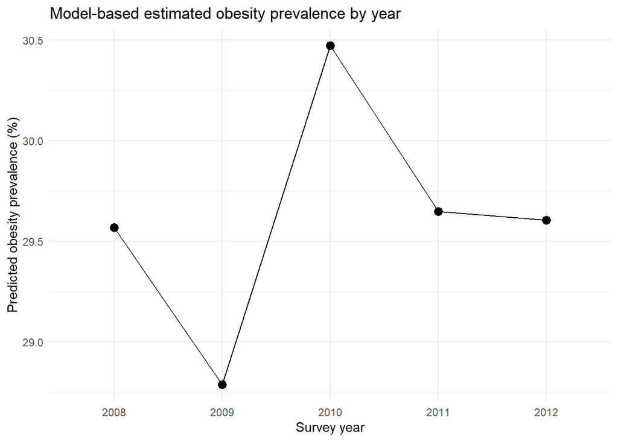

There is no statistically significant evidence that obesity prevalence in Scotland changed over the period 2008–2012. Both the categorical year model and the linear trend model suggest that obesity prevalence remained broadly stable across these survey years.

To investigate whether obesity differed by age, gender, socio-economic status and lifestyle factors, we fitted a binomial logistic regression model with obesity status as the response variable. The response variable Obese was binary, with Yes indicating an obese individual and No otherwise. The explanatory variables included age, sex, education level, vegetable intake and fruit intake. Logistic regression was appropriate because it models a binary outcome using the logit link, ensuring fitted probabilities remain within the unit interval.

There may be an interactive relationship between age and gender parameters in the model. Compare pure additive models and interaction models with age and gender using AIC. The AIC of the interaction model is smaller, so the interaction model should be chosen.

```
# Comparison of Model Performance Indices

Name        | Model |   AIC (weights)
-------------------------------------
model_add   |   glm | 30271.3 (0.004)
model_inter |   glm | 30260.2 (0.996)
```

$$Y_i \sim \text{Bernoulli}(p_i)$$

$$\log\left(\frac{p_i}{1-p_i}\right)
=
\beta_0 + \beta_1 Age_i + \beta_2 Sex_i + \beta_3 (Age_i \times Sex_i)
+ \sum_{j=1}^{5} \beta_{4j} Education_{ij}
+ \beta_5 Veg_i + \beta_6 Fruit_i$$

• $𝑌_𝑖$ is the obesity status of the $𝑖^{𝑡ℎ}$ individual (1 = obese, 0 = not obese);

• $𝑝_𝑖=𝑃(𝑌_𝑖=1)$ is the probability that the $𝑖^{𝑡ℎ}$ individual is obese;

• $𝛽_0$ is the intercept of the logistic regression model;

• $𝛽_1$ represents the change in the log-odds of obesity for a one increase in age for female.

• $𝛽_2$ represents the difference in the log-odds of obesity between the two sex groups when age is 0;

• $𝛽_3$ represents the interaction effect between age and sex, that is, how the effect of age on the log-odds of obesity differs by sex;

• $𝛽_5$ and $𝛽_6$ are the regression coefficients for vegetable intake and fruit intake respectively;

• $𝐴𝑔𝑒_𝑖 ,𝑆𝑒𝑥_𝑖,𝐸𝑑𝑢𝑐𝑎𝑡𝑖𝑜𝑛_𝑖,𝑉𝑒𝑔_𝑖,𝐹𝑟𝑢𝑖𝑡_𝑖$are the explanatory variables for the $𝑖^{th}$ individual.

[output not shown]

```
Profiled confidence intervals may take longer time to compute.
  Use `ci_method="wald"` for faster computation of CIs.
```

|  | Obese |  |  |
| --- | --- | --- | --- |
| Predictors | Log-Odds | CI | p |
| (Intercept) | -1.02 | -1.17 – -0.87 | **<0.001** |
| Age | 0.01 | 0.01 – 0.01 | **<0.001** |
| Sex [Male] | -0.34 | -0.51 – -0.16 | **<0.001** |
| Education [Other school level] | -0.16 | -0.28 – -0.05 | **0.004** |
| Education [Standard grade or equiv] | -0.08 | -0.17 – 0.01 | 0.069 |
| Education [Higher grade or equiv] | -0.24 | -0.34 – -0.14 | **<0.001** |
| Education [HNC/D or equiv] | -0.15 | -0.26 – -0.04 | **0.006** |
| Education [Degree or higher] | -0.39 | -0.47 – -0.31 | **<0.001** |
| Veg [Yes] | -0.14 | -0.21 – -0.08 | **<0.001** |
| Fruit [Yes] | 0.00 | -0.06 – 0.06 | 0.948 |
| Age × Sex [Male] | 0.01 | 0.00 – 0.01 | **<0.001** |
| Observations | 25224 |  |  |
| R<sup>2</sup> Tjur | 0.016 |  |  |

```
  threshold sensitivity specificity
1 0.2858467   0.6219039   0.5018305
```

```
# A tibble: 5 × 3
  .metric  .estimator .estimate
  <chr>    <chr>          <dbl>
1 accuracy binary         0.537
2 sens     binary         0.622
3 spec     binary         0.502
4 ppv      binary         0.344
5 npv      binary         0.759
```

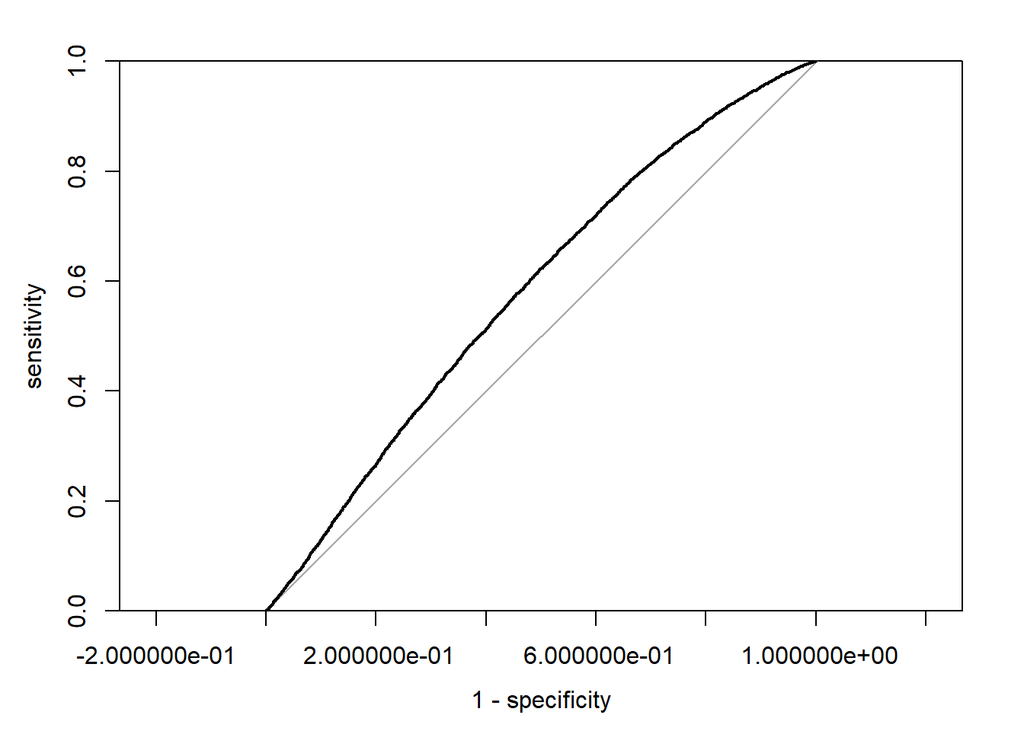

The best cut-off probability was approximately 0.28, which provides a balance between sensitivity and specificity. The model achieves an accuracy of 0.537, with sensitivity of 0.622 and specificity of 0.502, indicating moderate ability to identify obese individuals and have limited ability to correctly classify non-obese individuals. The ROC curve lies above the diagonal reference line, suggesting that the model performs better than random classification, although the overall discriminative ability remains relatively modest.

# 4 Conclusions

Obesity prevalence in Scotland is influenced by demographic and socio-economic factors, with higher rates observed among older individuals and those with lower educational attainment. While lifestyle factors such as diet show some association, their effects are less pronounced when other variables are considered. The logistic regression model captures these relationships to a limited extent, performing better at identifying obese individuals than non-obese ones. Overall, the findings suggest that obesity is shaped by multiple interacting factors and that effective interventions should focus on higher-risk groups and broader socio-economic conditions.